# EDA_job

# Internship versus Full-time roles:

Let us see how many roles are fulltime and how many are for students:

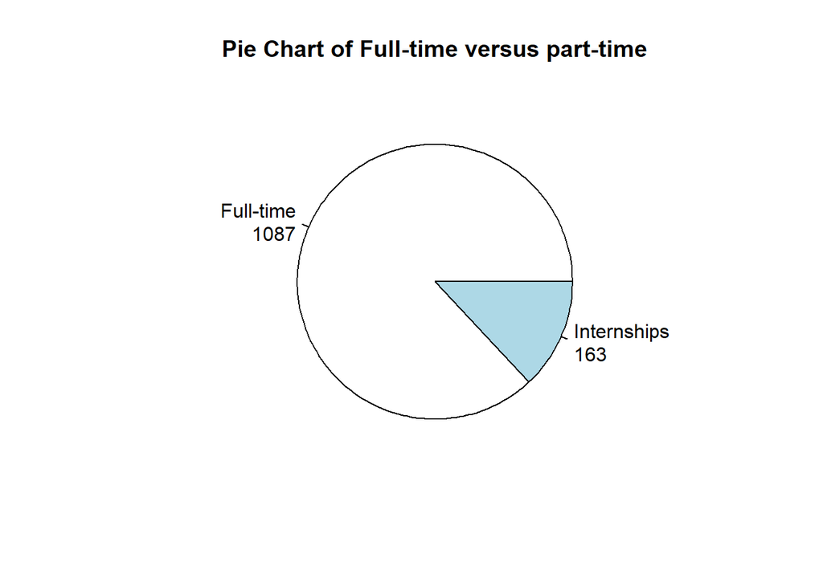

```r
google_skills$job_fte <- ifelse( (grepl("Intern ", google_skills$Title)) == TRUE, "Internships",
                            ifelse( (grepl("Intern,", google_skills$Title)) == TRUE, "Internships", "Full-time"))


mytable <- table(google_skills$job_fte)
lbls <- paste(names(mytable), "\n", mytable, sep="")
pie(mytable, labels = lbls,
    main="Pie Chart of Full-time versus part-time")
```

As expected, only ~13% of roles are for students i.e. internships.

# Technical Roles:

Since Google is pre-dominantly technical company, let us see how many positions need technical skills, irrespective of the business unit (job category)

1. Roles related to “Google Cloud”. So we look for the phrase either in the job title or the responsibilities:

```
##
##   cloud regular
##     285     965
```

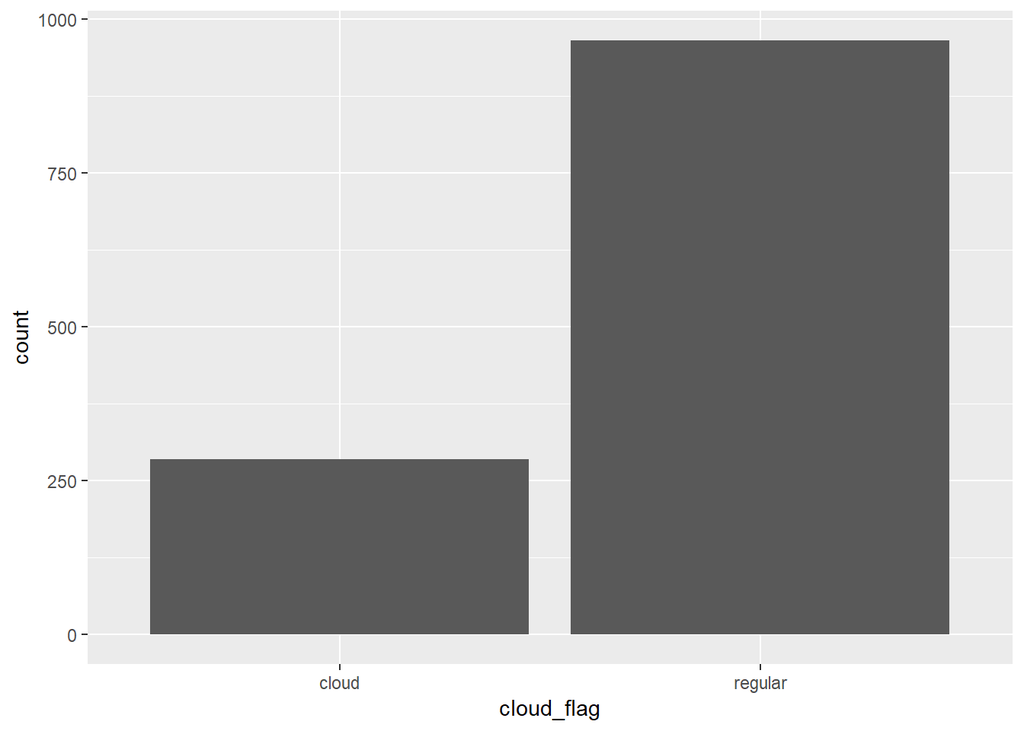

# Educational Qualifications:

1. What is the minimum qualification needed for these roles?

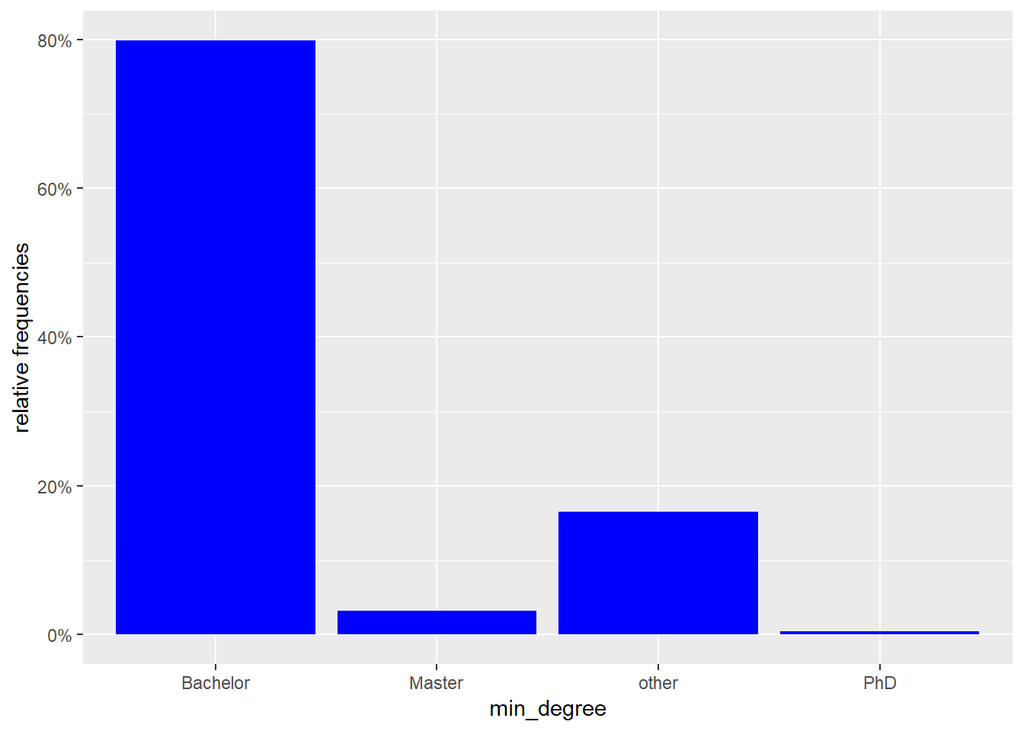

80% of the roles need a minimum of Bachelors degree.

2. What is the preferred qualification needed for these roles?

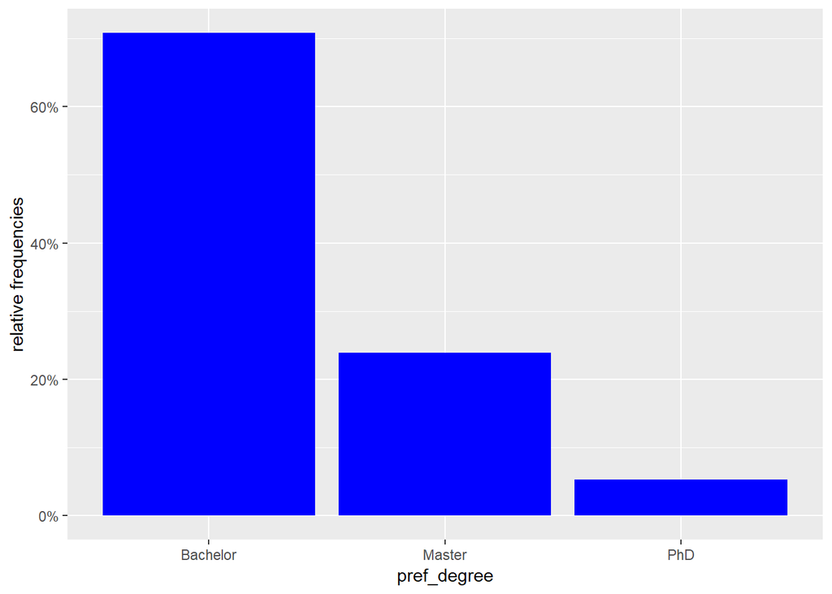

# Google Engineers:

Google is famous for hiring engineers for all types of roles. How many roles need a technical or Engineering degree in Engineering? As seen in the graph below, 35% of roles need technical expertise, including those in marketing and non-engineering roles.

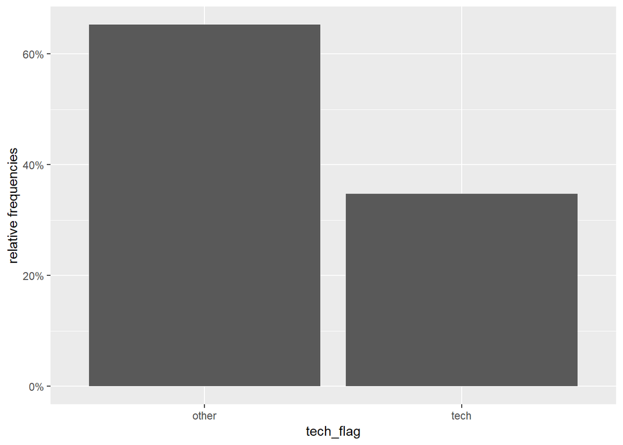

# Role Locations:

The dataset does not have the geographical coordinates for mapping. So we solve the problem by using the geocode() function and the amazing Rworldmap package. We are only plotting the locations, so some places would have more roles than others. So, we see open roles in all parts of the world. However, the maximum positions are in US, followed by UK, and then Europe as a whole.

The geocode function takes a while (10+ mins) and hence the script may terminate, hence commenting this part of the code. If you uncomment the code and run on your local machine, the script is a lot faster (2-3 mins max). Once the script completes, you should see a gray world map, with blue city markers showing the locations of the job postings. (image link below)

[Google open roles across the world] https://github.com/anurajaram/images/blob/master/google_job_locations.jpg

# Responsibilities - Word Cloud:

Let us create a word cloud to see what skills are most needed for the Cloud engineering roles: We see that words like “partner”, “custom solutions”, “cloud”, strategy“,”experience" are more frequent than any specific technical skills. This shows that the Google cloud roles are best filled by senior resources where leadership and business skills become more significant than expertise in a specific technology.

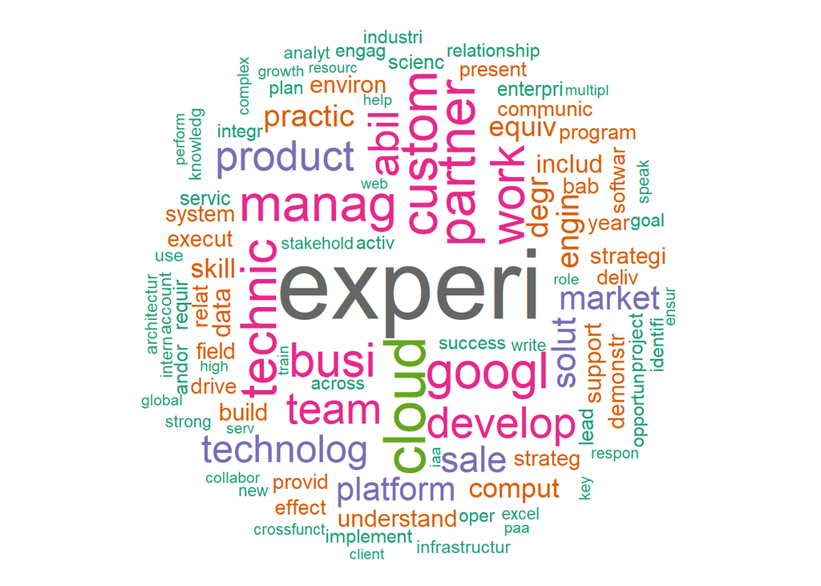